# reslr: Statistical Models for examining Relative Sea Level Change in R

Maeve Upton, Andrew Parnell & Niamh Cahill

2023-05-16

# Introduction

If you require fast instructions, check out the reslr: quick start vignette.

`reslr` is a package designed to account for measurement errors within commonly used models (e.g. linear regression, change-point regression, Integrated Gaussian process regression, splines, generalised additive models) for examining data in time and space. The package has the ability to utilise data derived from paleoenvironmental reconstructions. One such example is estimating Relative Sea Level (RSL) over time and space using a variety of different model types within a Bayesian Framework. This guide is developed for researchers interested in examining RSL historic change that varies in time or in time and space and how the RSL signal can be decomposed into a fundamental components.

There are a number of modelling options available to the user:

[output not shown]

For all of the above models the user is able to quantify and visualise changes of RSL and rates of change with associated uncertainties. Indeed a full posterior distribution ensemble of values is available in the output of the functions. For the decomposed full model, **“ni_gam_decomp”**, the user is able to access the posterior probability distributions of the individual components.

# Installation of the `reslr` package

The `reslr` package uses the JAGS (Just Another Gibbs Sampler) software to run the models. Before installing `reslr`, visit the [JAGS](https://sourceforge.net/projects/mcmc-jags/) website and download and install JAGS for your operating system.

Next, start Rstudio and find the window with the command prompt (the symbol `>`). Type

```r
# install.packages("reslr")
# library(devtools)
# devtools::install()
devtools::install_github("maeveupton/reslr")
```

It may ask you to pick your nearest CRAN mirror (the nearest site which hosts R packages). You will then see some activity on the screen as the `reslr` package and the other packages it uses are downloaded. The final line should then read:

`package 'reslr' successfully unpacked and MD5 sums checked`

You then need to load the package.

```r
library(reslr)
```

This will load the `reslr` package and all the associated packages. You’ll need to type the `library(reslr)` command every time you start R. If you have problems, visit the [Issues](https://github.com/maeveupton/reslr/issues) page and leave a message to tell us what went wrong.

# Considerations before running reslr

Prior to running the `reslr` package, there are a few points to consider.

## Installating JAGS software

In this package, the models are written using Just Another Gibbs Sample (JAGS) which uses Gibbs sampling and Markov Chain Monte Carlo (MCMC) algorithm to draw samples from the posterior distribution of the unknown parameters. To download the JAGS package use this [link](https://sourceforge.net/projects/mcmc-jags/).

## Working with scripts

The best way to use the `reslr` package is by creating scripts. A script can be created in Rstudio by clicking `File > New File > Rscript`. This opens a text window which allows commands to be typed in order and saved. The command can be sent to the command prompt (which Rstudio calls the Console) by highlighting the command and clicking Run (or going to Code > Run Lines). There are also keyboard shortcuts to speed up the process. We strongly recommend you learn to run R via scripts.

## Inputting User’s data

`reslr` can handle three different types of data structure. It is important to note that varying the number of data sites will require different statistical modelling strategy:

- A single site. This may occur when you have data for only one individual data site. In the case of a single site, we recommend using a temporal model, for example EIV Integrated Gaussian Process or NI spline in time.
- Multiple sites. This may occur if you have a dataset which has multiple different data sites. In this situation, the user must use a spatial temporal model, for example NI spline in space time.
- Multiple group of sites with different drivers of change. This may occur if you have multiple locations are interested in investigating how the regional, linear local and non-linear local components vary. In this case, the NI GAM decomposition is recommended.

The user must ensure that the input data is a dataframe. For a single site or multiple sites only one dataframe should be given to the package, i.e. combined all sites into one dataframe, with the following columns names:

| Site | Region | Age | Age_err | RSL | RSL_err | Longitude | Latitude | linear_rate | linear_rate_err |  |
| --- | --- | --- | --- | --- | --- | --- | --- | --- | --- | --- |
| “Leeds Point” | “New Jersey” | 1000 | 8 | 0.5 | 0.01 | 39.5 | - 74.4 | 1.69 | 0.03 |  |
| “Leeds Point” | “New Jersey” | 1050 | 11 | 0.6 | 0.01 | 39.5 | - 74.4 | 1.69 | 0.03 |  |
| … | … | … | … | … | … | … | … | … | … |  |
| … | … | … | … | … | … | … | … | … | … |  |
| … | … | … | … | … | … | … | … | … | … |  |
| “Cedar Island” | “North Carolina” | 1700 | 12 | 0.8 | 0.06 | -76.4 | 35 | 0.74 | 0.01 |  |
| … | … | … | … | … | … | … | … | … | … |  |
| … | … | … | … | … | … | … | … | … | … |  |

- Site is the name of the site in question, e.g. Leeds Point.
- Region is the area in which is was collected, e.g. New Jersey. To note, in the package, the Site and the Region columns will be combined to form a factor called the `SiteName` which results in an output, e.g. “Leeds Point,New Jersey”.
- Age is the year of the data in Common era (“CE”) or Before Present (“BP”). If calibrated in the BP form the package will convert the data into the Common Era form.
- Age_err is the 1 standard deviation ($\sigma$) Age uncertainty associated with the Age.
- RSL is the Relative Sea Level measured in meters.
- RSL_err is the 1 standard deviation ($\sigma$) Relative Sea level uncertainty associated with the RSL measured in meters.
- Longitude is the longitude of the site in degrees (in decimal, range: -180 to 180). It is important to note that if there are slightly different longitude values for all the observations in site this will lead to errors. Therefore, select one longitude value for each site.
- Latitude is the Latitude of the site in degrees (degree in decimal, range -90 to 90). Similarly, it is important to note that if there are slightly different latitude values for all the observations in site this will lead to errors. Therefore, select one latitude value for each site.
- **Optional** linear_rate is a column that contains the linear rate in mm per year associated with that site, arising from processes such as glacial isostatic adjustment (GIA). *This is not a requirement*. For the NI GAM decomposition model, the user has the option of using their own rate, otherwise the package will calculate it using the data. It is important to note that if the linear_rate is provided without the linear_rate_err column this will lead to issues, i.e. both columns need to be provided
- **Optional** linear_rate_err is a column that contains associated uncertainty for the linear rate in mm per year. *This is not a requirement*. For the NI GAM decomposition model, the user has the option of using their value, otherwise the package will calculate it using the data. It is important to note that if the linear_rate_err is provided without the linear_rate column this will lead to issues, i.e. both columns need to be provided.

## Tide Gauge Data

There is an option in the `reslr` package to include tide gauge data as an additional source of data which we recommend when using the `model_type = "ni_gam_decomp"`. The package will extract tide gauge data from the [PSMSL website](https://psmsl.org/data/obtaining/complete.php). The data is downloaded from this website and stored in a temporary directory. The tide gauges undergo a cleaning process within the package. Firstly, certain tide gauges have been flagged by the PSMSL website and we remove these locations. As collection of proxy reconstructions began in approximately 2000 CE, the tide gauge records are given in meters relative to the average over a time window, 2000 - 2018 CE, which corresponds to the variability of 19-year astronomical tides (Pugh and Woodworth 2014). Next, the tide gauge data is averaged over a decade to make it comparable with sedimentation rates associated proxy records sedimentation rates. The user can alter the size of the average if required when accumulation rates for the sediment in the proxy record is estimated to have a higher or lower accumulation rate, e.g. longer sediment accumulation rate result in a larger window average of 20 years.

The user can select a combination of option 1 and option 2 or option 1 and option 3 which allows for additional tide gauge data to be included. The final output is a data frame which contains an additional column, called `data_type_id`, identifying the data source “ProxyRecord” or “TideGaugeData” depending on the observation in question.

## Glacial Isostatic Adjustment (GIA)

For the NI GAM decomposition, the statistical model requires an estimate for the local linear rate arising from processes such as GIA and associated uncertainty for this rate each site. According to Whitehouse (2018), GIA represents the Earth’s reaction to the growth or melting of ice sheets, including the gravitational field and ocean. GIA can be approximated as a linear contribution over a short timescale, but with variable effects along the coast (Engelhart et al., 2009). Earth-ice models, which incorporate the physical structure of the Earth to predict GIA changes due to ice loading and unloading, can provide estimates of GIA rates. There are a range of Earth-ice models with one such example being the ICE5G VM2-90 (Peltier, 2004). It should be noted that other processes, such as tectonic vertical land motion, can mimic the linear trend of GIA. Therefore, the linear local component within the NI GAM decomposition may account for contributions from processes other than GIA that drive changes in relative sea level. These are included as additional columns, `linear_rate` and `linear_rate_err`, in the input dataframe provided by the user.

If the GIA rate for the proxy site is not provided then package will automatically calculate these rates using the data provided and we do not estimates the rates from any Earth-ice physical model. The user can source their own rate estimates as previously mentioned. Two examples of GIA rate sources (not limited to) include [Prof. Peltier’s webpage](https://www.atmosp.physics.utoronto.ca/~peltier/data.php) and the associated publication (Peltier, 2004) or the Caron et al. 2018 publication and [data](https://vesl.jpl.nasa.gov/solid-earth/gia/).

Important to note, the tide gauge data require values for the `linear_rate` and `linear_rate_err` columns. This is calculated using [Peltier’s Earth ice model: ICE5G](https://www.atmosp.physics.utoronto.ca/~peltier/data.php) with an uncertainty value of 0.3 mm/year from [Englehart et al 2009](https://eartharxiv.org/repository/view/1157/).

## Example Data Set

The `reslr` package possesses a large dataset used as an example called `NAACproxydata`. This dataset contains proxy records from the Atlantic coast of North America as used in Upton et al 2023 along with tide gauge data which will be discussed below. The 21 different proxy data sites and the references for each data source can be found in the following table:

| Site Name | Reference |
| --- | --- |
| Barn Island, Connecticut | [Donnelly et al (2004)](https://agupubs.onlinelibrary.wiley.com/doi/full/10.1029/2003GL018933), [Gehrels et al (2020)](https://agupubs.onlinelibrary.wiley.com/doi/full/10.1029/2019GL085814) |
| Big River Marsh, Newfoundland | [Kemp et al (2018)](https://doi.org/10.1016/j.quascirev.2018.10.012) |
| Cape May Courthouse, New Jersey | [Kemp et al (2013)](https://doi.org/10.1016/j.quascirev.2013.09.024), [Cahill et al (2016)](https://doi.org/10.5194/cp-12-525-2016) |
| Cedar Island, North Carolina | [Kemp et al (2011)](https://doi.org/10.1073/pnas.1015619108), [Kemp et al (2017)](https://doi.org/10.1177/0959683616683263) |
| Cheesequake, New Jersey | [Walker et al (2021)](https://www.nature.com/articles/s41467-021-22079-2) |
| Chezzetcook Inlet, Nova Scotia | [Gehrels et al (2020)](https://agupubs.onlinelibrary.wiley.com/doi/full/10.1029/2019GL085814) |
| East River Marsh, Connecticut | [Kemp et al (2015)](https://doi.org/10.1016/j.epsl.2015.07.034), [Stearns et al (2023)](https://www.sciencedirect.com/science/article/pii/S0277379122004991) |
| Fox Hill Marsh, Rhode Island | [Stearns et al (2023)](https://www.sciencedirect.com/science/article/pii/S0277379122004991) |
| Leeds Point, New Jersey | [Kemp et al (2013)](https://doi.org/10.1016/j.quascirev.2013.09.024), [Cahill et al (2016)](https://doi.org/10.5194/cp-12-525-2016) |
| Les Sillons, Magdelen Islands | [Barnett et al (2017)](https://doi.org/10.1002/jqs.2931) |
| Little Manatee River, Florida | [Gerlach et al (2017)](https://doi.org/10.1016/j.margeo.2017.07.001) |
| Nassau, Florida | [Kemp et al (2014)](https://www.sciencedirect.com/science/article/pii/S0025322714002187?via%3Dihub) |
| Pelham Bay, New York | [Kemp et al (2017)](https://doi.org/10.1177/0959683616683263), [Stearns et al (2017)](https://doi.org/10.23860/thesis-stearns-rachel-2017) |
| Placentia, Newfoundland | [Kemp et al (2018)](https://doi.org/10.1016/j.quascirev.2018.10.012)) |
| Revere, Massachusetts | [Donnelly et al (2006)](https://www.jstor.org/stable/4300372) |
| Saint Simeon, Quebec | [Barnett et al (2017)](https://doi.org/10.1002/jqs.2931) |
| Sanborn Cove, Maine | [Gehrels et al (2020)](https://agupubs.onlinelibrary.wiley.com/doi/full/10.1029/2019GL085814) |
| Sand Point, North Carolina | [Kemp et al (2011)](https://doi.org/10.1073/pnas.1015619108), [Kemp et al (2017)](https://doi.org/10.1177/0959683616683263) |
| Snipe Key, Florida | [Khan et al (2022)](https://doi.org/10.1016/j.gloplacha.2022.103902) |
| Swan Key, Florida | [Khan et al (2022)](https://doi.org/10.1016/j.gloplacha.2022.103902) |
| Wood Island, Massachusetts | [Kemp et al (2011)](https://doi.org/10.1073/pnas.1015619108) |

The `NAACproxydata` is a data frame with 1715 rows and 8 columns which include:

- Region: All regions along Atlantic coast of North America
- Site: All sites along Atlantic coast of North America
- Latitude: Latitude of the data site
- Longitude: Longitude of the data site
- RSL: Relative Sea level in meters
- RSL_err: 1 standard deviation error associated with relative sea level measured in meters
- Age: Age in years common era (CE)
- Age_err: 1 standard deviation error associated with the Age in years CE

If you are interested in a specific site or multiple sites from the example dataset, then filter for that site prior to running the package, using the following method:

```r
# For 1 site
data_1site <- reslr::NAACproxydata %>% dplyr::filter(Site == "Cedar Island")
# For multiple sites
data_multisite <- reslr::NAACproxydata %>% dplyr::filter(Site %in% c(
  "Snipe Key", "Cheesequake",
  "Placentia", "Leeds Point"
))
```

# How to run reslr

The general structure for running `reslr` is as follows:

**Step 1.** Load in the data using `reslr_load`. If tide gauge data required update the argument `include_tide_gauge = TRUE`, from this the user has three options as described above. Firstly, provide the list of names for the tide gauges from PSMSL website that the wish to use in the `list_preferred_TGs` option. Secondly, the package find the tide gauge closest to the proxy site `TG_minimum_dist_proxy = TRUE`. Thirdly, the package uses all tide gauges within 1 degree of the proxy site `all_TG_1deg = TRUE`. If sedimentation accumulation rates for the proxy records are less than or greater than a decade the user can alter this size using `sediment_average_TG = 10` which has a default of 10 years. If linear_rate is of interest to the user update the argument `include_linear_rate = TRUE`. The user can select the resolution of the output by changing the value of `prediction_grid_res = 50` with the default of 50 years. The `input_Age_type` argument is associated with the type of input Age where the default is in Common Era.

**Step 1a.** The `print` function provides a brief insight into the inputted data.

**Step 2.** Plot the raw data using `plot` and select whether to include tide gauges in the output plot. The user can update the title (`plot_title`) and axis labels (`xlab`,`ylab`). The captions (`plot_captions`) can be included on the plots which provides a summary of the number of proxy sites and tide gauge sites.

**Step 3.** Choose your preferred model type from the available list above and use the `reslr_mcmc` function to obtain the parameter estimates and the dataframes required for plotting the outputs. This function has a number of settings which allow the user to improve model diagnostics. In addition, this function allows the user to chose their preferred credible interval size, the default setting is `CI = 0.95`.

**Step 3a.** The `print` function provides a brief insight into the output of the `reslr_mcmc` function.

**Step 4.** Check the model converged and examine the results of the parameters with the `summary` function

**Step 5.** Visualise the results with `plot` and access the dataframes used to create the plots. The `plot_type` option allows users to print individual plots, for example the model fits (“model_fit_plot”) and the rates (“rate_plot”) separately. The captions (`plot_captions`) can be included on the plots which provides a summary of the model type, the number of proxy sites and tide gauge sites. The user can select to include the tide gauge (`plot_tide_gauges`) in the output plots.

# Errors-in-Variables Simple Linear Regression (**“eiv_slr_t”**)

The simplest model the `reslr` package can fit is a simple linear regression using the Errors-in-Variables method to account for the uncertainty associated with the proxy records, i.e. uncertainty associated with input (age) and the output (RSL). We would not recommend any model simpler than this (e.g. `lm`) as it will ignore some of the key uncertainties in the data.

This technique focuses on 1 site and is not recommended for multiple proxy sites together. Tide gauge data can be included to gain insight into recent changes in RSL, however, the user must investigate which tide gauge is suitable. As an example, we will filter the example dataset `NAACproxydata` to select one site to demonstrate the process:

```r
# For 1 site
CedarIslandNC <- reslr::NAACproxydata %>% dplyr::filter(Site == "Cedar Island")
```

**Step 1:** Load in the data using the `reslr_load` function:

```r
CedarIslandNC_input <- reslr_load(
  data = CedarIslandNC,
  include_tide_gauge = FALSE,
  include_linear_rate = FALSE,
  TG_minimum_dist_proxy = FALSE,
  list_preferred_TGs = NULL,
  all_TG_1deg = FALSE,
  prediction_grid_res = 50,
  input_Age_type = "CE",
  sediment_average_TG = 10
)
```

The output of this function is a list of two dataframes called `data` and `data_grid`.

- The `data` dataframe is the inputted data with additional columns for the linear_rate, linear_rate_err and data_type_id which will contain two options, “ProxyRecord” or “TideGaugeData”. It can be accessed by:

```r
data <- CedarIslandNC_input$data
```

- The `data_grid` is a dataframe that is evenly spaced in time based on the `prediction_grid_res` value chosen by the user and is used to create the plots and is accessed by

```r
data_grid <- CedarIslandNC_input$data_grid
```

**Step 1a:** A brief insight into the outputs of the `reslr_input` function can be obtained using:

```r
print(CedarIslandNC_input)
```

```
#> This is a valid reslr input object with 104 observations and  1 site.
#> There is  1  proxy site and  0  tide gauge site.
#> The age units are; Common Era.
#> No decadally averaged yide gauge data included. It is recommended for the ni_gam_decomp model
#> No linear_rate or linear_rate_err included. It is required for the ni_gam_decomp model
```

**Step 2:** Plotting the data the raw data with:

```r
plot(
  x = CedarIslandNC_input,
  title = "Plot of the raw data",
  xlab = "Year (CE)",
  ylab = "Relative Sea Level (m)",
  plot_tide_gauges = FALSE,
  plot_proxy_records = TRUE,
  plot_caption = TRUE
)
```

This will produce a plot of Age on the x-axis and Relative Sea Level on the y-axis in meters. Grey boxes represent the uncertainty associated with the vertical and horizontal uncertainty. The black data points are the midpoints of these uncertainty boxes. The following extra arguments can be used which allows the user to updated the titles and axis labels. The caption `plot_caption`, included by default, provides the number of proxy sites and tide gauge sites that will be used in the model and can be removed if required `plot_caption = FALSE`. In addition, the user can select to plot the additional tide gauge data, `plot_tide_gauge = TRUE`.

**Step 3:** To run the the model the following code is used:

```r
res_eiv_slr_t <- reslr_mcmc(
  input_data = CedarIslandNC_input,
  model_type = "eiv_slr_t",
  CI = 0.95
)
```

This command takes the input data and the user specifies the statistical model, i.e. a simple linear regression using the EIV uncertainty method (“eiv_slr_t”). The `CI` setting allows the user to set the credible intervals, the current default is `CI = 0.95`. The function tells `reslr` to store the output of the model run in an object called `res_eiv_slr_t`.

**Step 3a:** A brief insight into the outputs of the `reslr_output` function can be obtained using:

```r
print(res_eiv_slr_t)
```

```
#> This is a valid reslr output object with 104 observations and  1 site.
#> There is  1  proxy site and  0  tide gauge site.
#> The age units are; Common Era.
#> The model used was the Errors-in-Variables Simple Linear Regression model.
#> The input data has been run via reslr_mcmc and has produced 3000 iterations over 3 MCMC chains.
```

**Step 4:** The convergence of the algorithm is examined and he parameter estimates from the model can be investigated using the following:

```r
summary(res_eiv_slr_t)
```

```
#> No convergence issues detected.
#> # A tibble: 3 × 7
#>   variable    mean      sd     mad      q5     q95  rhat
#>   <chr>      <num>   <num>   <num>   <num>   <num> <num>
#> 1 alpha    -1.99   0.0169  0.0175  -2.02   -1.96    1.00
#> 2 beta      0.823  0.0128  0.0128   0.801   0.844   1.00
#> 3 sigma_y   0.0665 0.00927 0.00899  0.0511  0.0818  1.00
```

If the model run has the package will print: “No convergence issues detected”. If the package prints: “Convergence issues detected, a longer run is necessary”. The user is required to update the `reslr_mcmc` function with additional iterations in the following manner:

```r
res_eiv_slr_t <- reslr_mcmc(
  input_data = CedarIslandNC_input,
  model_type = "eiv_slr_t",
  # Update these values
  n_iterations = 6000, # Number of iterations
  n_burnin = 1000, # Number of iterations to discard at the beginning
  n_thin = 4, # Reduces number of output samples to save memory and computation time
  n_chains = 3 # Number of Markov chains
)
```

The output of this function allows to user to examine the parameter estimates. For the eiv_slr_t model, the parameters of interest are the intercept (“alpha”), the slope (“beta”) and the residual standard deviation of the model (“sigma_y”). When using the eiv_slr_t model, an estimate of the of the rate of sea-level change can be obtained by examining the value of the slope, i.e. “beta”.

**Step 5:** The results from the eiv_slr_t model can be visualised using the following function:

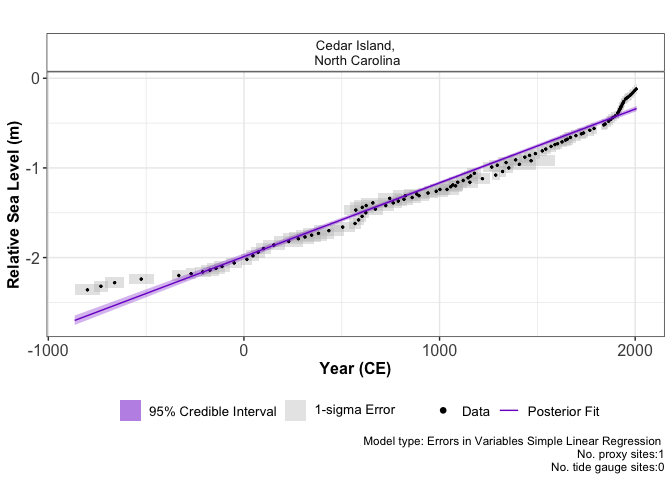

```r
plot(res_eiv_slr_t,
  xlab = "Year (CE)",
  ylab = "Relative Sea Level (m)"
)
```

The output of this function is a graph of the input data, i.e. Age and RSL and associated uncertainty boxes, and the model fit with 95 % credible interval. The caption provides the model type used and number of proxy sites and tide gauge sites used and can be removed if necessary with `plot_caption = FALSE`.

To examine the data creating these plots the user types the following:

```r
output_dataframes <- res_eiv_slr_t$output_dataframes
head(output_dataframes)
```

```
#>   Longitude Latitude                       SiteName data_type_id     Age
#> 1    -76.38   34.971 Cedar Island,\n North Carolina  ProxyRecord -865.25
#> 2    -76.38   34.971 Cedar Island,\n North Carolina  ProxyRecord -750.00
#> 3    -76.38   34.971 Cedar Island,\n North Carolina  ProxyRecord -700.00
#> 4    -76.38   34.971 Cedar Island,\n North Carolina  ProxyRecord -650.00
#> 5    -76.38   34.971 Cedar Island,\n North Carolina  ProxyRecord -600.00
#> 6    -76.38   34.971 Cedar Island,\n North Carolina  ProxyRecord -550.00
#>        pred       upr       lwr  CI
#> 1 -2.701131 -2.751835 -2.646541 95%
#> 2 -2.606308 -2.654182 -2.554543 95%
#> 3 -2.565170 -2.611807 -2.514522 95%
#> 4 -2.524032 -2.569417 -2.474700 95%
#> 5 -2.482894 -2.527103 -2.434430 95%
#> 6 -2.441757 -2.484987 -2.394149 95%
```

# Errors-in-Variable Change Point Model (**“eiv_cp_t”**)

The Errors-in-Variable Change Point model is an extension of the linear regression and allows the user to specify the number of change points required.

This technique focuses on 1 site and the maximum number of change points available to the user is 3. We do not recommended for multiple proxy sites together. Tide gauge data can be included to gain insight into recent changes in RSL, however, the user must investigate which tide gauge is most suitable. It is important to note that certain data sites will not work with 2 or 3 change points as there is no distinct changing points in the data. In this case, we recommend testing different number of change points and reviewing the resulting plots to confirm the correct number of change points is selected.

As an example, we will filter the example dataset `NAACproxydata` to select one site to demonstrate the process:

```r
# For 1 site
CedarIslandNC <- reslr::NAACproxydata %>% dplyr::filter(Site == "Cedar Island")
```

**Step 1:** Load in the data using the `reslr_load` function:

```r
CedarIslandNC_input <- reslr_load(
  data = CedarIslandNC,
  include_tide_gauge = FALSE,
  include_linear_rate = FALSE,
  TG_minimum_dist_proxy = FALSE,
  list_preferred_TGs = NULL,
  all_TG_1deg = FALSE,
  prediction_grid_res = 50,
  sediment_average_TG = 10
)
```

In this function, the user can select to add tide gauge data and estimates for linear_rate, by changing `include_tide_gauge = TRUE` and `include_linear_rate = TRUE` respectfully. If `include_tide_gauge = TRUE` the user must decide if they require the closest tide gauge i.e. `TG_minimum_dist_proxy = TRUE`, or select specific tide gauge i.e. `list_preferred_TGs = c("ARGENTIA")`, or all tide gauges within 1 degree of the proxy site i.e. `all_TG_1deg = TRUE`. The default setting is `sediment_average_TG = 10` which corresponds to sediment accumulation rates of the proxy records, yet the user has the ability to alter this sediment accumulation rate by changing the size of the rolling window average.

Note that for a change point model, we recommend using the default settings as demonstrated in the above code chunk. The user can alter the resolution of the output plots using `prediction_grid_res` with the default set at 50 years. The output of this function is a list of two dataframes called `data` and `data_grid`. - The `data` dataframe is the inputted data with additional column for the data_type_id which will contain, “ProxyRecord”. It can be accessed by:

```r
data <- CedarIslandNC_input$data
head(data)
```

```
#>           Region         Site Latitude Longitude   RSL  Age Age_err RSL_err
#> 1 North Carolina Cedar Island   34.971    -76.38 -0.12 2005    2.25    0.06
#> 2 North Carolina Cedar Island   34.971    -76.38 -0.14 1996    2.00    0.06
#> 3 North Carolina Cedar Island   34.971    -76.38 -0.16 1988    5.00    0.06
#> 4 North Carolina Cedar Island   34.971    -76.38 -0.18 1979    5.75    0.06
#> 5 North Carolina Cedar Island   34.971    -76.38 -0.19 1974    5.50    0.06
#> 6 North Carolina Cedar Island   34.971    -76.38 -0.21 1963    5.50    0.06
#>                         SiteName data_type_id
#> 1 Cedar Island,\n North Carolina  ProxyRecord
#> 2 Cedar Island,\n North Carolina  ProxyRecord
#> 3 Cedar Island,\n North Carolina  ProxyRecord
#> 4 Cedar Island,\n North Carolina  ProxyRecord
#> 5 Cedar Island,\n North Carolina  ProxyRecord
#> 6 Cedar Island,\n North Carolina  ProxyRecord
```

- The `data_grid` is a dataframe that is evenly spaced in time based on the `prediction_grid_res` value chosen by the user and is used to create the plots and is accessed by

```r
data_grid <- CedarIslandNC_input$data_grid
head(data_grid)
```

```
#> # A tibble: 6 × 5
#> # Groups:   SiteName [1]
#>   Longitude Latitude SiteName                         data_type_id   Age
#>       <dbl>    <dbl> <fct>                            <fct>        <dbl>
#> 1     -76.4     35.0 "Cedar Island,\n North Carolina" ProxyRecord  -865.
#> 2     -76.4     35.0 "Cedar Island,\n North Carolina" ProxyRecord  -750
#> 3     -76.4     35.0 "Cedar Island,\n North Carolina" ProxyRecord  -700
#> 4     -76.4     35.0 "Cedar Island,\n North Carolina" ProxyRecord  -650
#> 5     -76.4     35.0 "Cedar Island,\n North Carolina" ProxyRecord  -600
#> 6     -76.4     35.0 "Cedar Island,\n North Carolina" ProxyRecord  -550
```

**Step 1a:** A brief insight into the outputs of the `reslr_input` function can be obtained using:

```r
print(CedarIslandNC_input)
```

```
#> This is a valid reslr input object with 104 observations and  1 site.
#> There is  1  proxy site and  0  tide gauge site.
#> The age units are; Common Era.
#> No decadally averaged yide gauge data included. It is recommended for the ni_gam_decomp model
#> No linear_rate or linear_rate_err included. It is required for the ni_gam_decomp model
```

**Step 2:** Plotting the data the raw data with:

```r
plot(
  x = CedarIslandNC_input,
  title = "Plot of the raw data",
  xlab = "Year (CE)",
  ylab = "Relative Sea Level (m)",
  plot_proxy_records = TRUE,
  plot_tide_gauges = FALSE
)
```

This will produce a plot of Age on the x-axis and Relative Sea Level on the y-axis in meters. Grey boxes represent the uncertainty associated with the vertical and horizontal uncertainty. The black data points are the midpoints of these uncertainty boxes. The extra arguments can be used which allows the user to updated the titles and axis labels. The caption `plot_caption`, included by default, provides the number of proxy sites and tide gauge sites that will be used in the model and can be removed if required `plot_caption = FALSE`. The user can select to plot the additional tide gauge data, `plot_tide_gauge = TRUE`.

**Step 3:** Run the model using the following code and select the number of change points you require:

```r
res_eiv_cp1_t <- reslr_mcmc(
  input_data = CedarIslandNC_input,
  model_type = "eiv_cp_t",
  n_cp = 1,
  CI = 0.95
)
```

If the user is interested in running 2 change points use method:

```r
res_eiv_cp2_t <- reslr_mcmc(
  input_data = CedarIslandNC_input,
  model_type = "eiv_cp_t",
  n_cp = 2, # Updating the default setting to include an additional change point.
  CI = 0.95
)
```

The `CI` setting allows the user to set the credible intervals, the current default is `CI = 0.95`. Similar to the earlier model, the output object `res_eiv_cp1_t` stores the JAGS model run and should take a second to run.

**Step 3a:** A brief insight into the outputs of the `reslr_output` function can be obtained using:

```r
print(res_eiv_cp1_t)
```

```
#> This is a valid reslr output object with 104 observations and  1 site.
#> There is  1  proxy site and  0  tide gauge site.
#> The age units are; Common Era.
#> The model used was the Errors-in-Variables Change Point model with 1 change point.
#> The input data has been run via reslr_mcmc and has produced 3000 iterations over 3 MCMC chains.
```

**Step 4:** The convergence of the algorithm is examined and the parameter estimates from the model can be investigated using the following:

```r
summary(res_eiv_cp1_t)
```

```
#> No convergence issues detected.
#> # A tibble: 5 × 7
#>   variable           mean     sd    mad       q5     q95  rhat
#>   <chr>             <num>  <num>  <num>    <num>   <num> <num>
#> 1 alpha           -1.25   0.600  0.760  -1.97    -0.566   1.00
#> 2 beta[1]          0.621  0.131  0.155   0.405    0.762   1.00
#> 3 beta[2]          1.59   0.795  0.121   0.887    2.96    1.00
#> 4 Change Point: 1019      0.731  0.941   0.140    1.84    1.00
#> 5 sigma_y          0.0193 0.0149 0.0168  0.00106  0.0459  1.00
```

If the model run has the package will print: “No convergence issues detected”. If the package prints: “Convergence issues detected, a longer run is necessary”. The user is required to update the `reslr_mcmc` function with additional iterations in the following manner:

```r
res_eiv_cp1_t <- reslr_mcmc(
  input_data = CedarIslandNC_input,
  model_type = "eiv_cp_t",
  # Update these values
  n_iterations = 6000, # Number of iterations
  n_burnin = 1000, # Number of iterations to discard at the beginning
  n_thin = 4, # Reduces number of output samples to save memory and computation time
  n_chains = 3 # Number of Markov chains
)
```

For the eiv_cp_t model, the parameters of interest are the intercept (alpha), the slopes before the change point (“beta[1]”) and after the change point (“beta[2]”), the year of the change point (Change Point) and “sigma_y” the variance of the model.

**Step 5:** The results from the EIV Change Point model can be illustrated using:

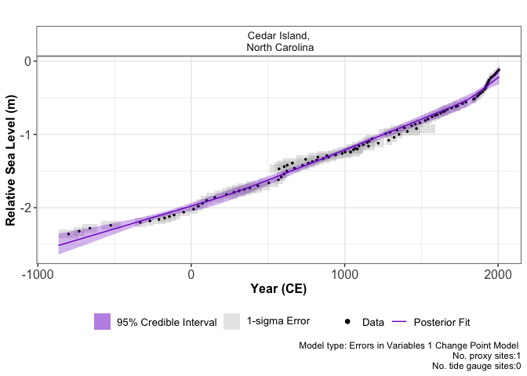

```r
plot(res_eiv_cp1_t,
  xlab = "Year (CE)",
  ylab = "Relative Sea Level (m)",
)
```

The output of this function is a graph of the input data, i.e. Age and RSL and associated uncertainty boxes, and the model fit with 95 % credible interval. The caption provides the model type used and number of proxy sites and tide gauge sites used and can be removed if necessary with `plot_caption = FALSE`.

To examine the data creating these plots the user types the following:

```r
output_dataframes <- res_eiv_cp1_t$output_dataframes
head(output_dataframes)
```

```
#>   Longitude Latitude                       SiteName data_type_id     Age
#> 1    -76.38   34.971 Cedar Island,\n North Carolina  ProxyRecord -865.25
#> 2    -76.38   34.971 Cedar Island,\n North Carolina  ProxyRecord -750.00
#> 3    -76.38   34.971 Cedar Island,\n North Carolina  ProxyRecord -700.00
#> 4    -76.38   34.971 Cedar Island,\n North Carolina  ProxyRecord -650.00
#> 5    -76.38   34.971 Cedar Island,\n North Carolina  ProxyRecord -600.00
#> 6    -76.38   34.971 Cedar Island,\n North Carolina  ProxyRecord -550.00
#>        pred       upr       lwr  CI
#> 1 -2.514788 -2.639124 -2.352671 95%
#> 2 -2.443188 -2.550612 -2.309329 95%
#> 3 -2.412125 -2.512346 -2.290155 95%
#> 4 -2.381063 -2.473984 -2.269421 95%
#> 5 -2.350000 -2.435614 -2.249010 95%
#> 6 -2.318937 -2.397262 -2.228144 95%
```

# Errors-in-Variable Integrated Gaussian Process Model (**“eiv_igp_t”**)

The EIV Integrated Gaussian Process model provides the underlying rate of the process directly from the model. Further reading on this modeling approach can be found [here](https://projecteuclid.org/journals/annals-of-applied-statistics/volume-9/issue-2/Modeling-sea-level-change-using-errors-in-variables-integrated-Gaussian/10.1214/15-AOAS824.full).

This technique focuses on 1 site and we do not recommended for multiple proxy sites together. Tide gauge data can be included to gain insight into recent changes in RSL, however, the user must investigate which tide gauge is suitable. As an example, we will filter the example dataset `NAACproxydata` to select one site to demonstrate the process:

```r
# For 1 site
CedarIslandNC <- reslr::NAACproxydata %>% dplyr::filter(Site == "Cedar Island")
```

**Step 1:** Load in the data using the `reslr_load` function:

```r
CedarIslandNC_input <- reslr_load(
  data = CedarIslandNC,
  include_tide_gauge = FALSE,
  include_linear_rate = FALSE,
  TG_minimum_dist_proxy = FALSE,
  list_preferred_TGs = NULL,
  all_TG_1deg = FALSE,
  prediction_grid_res = 50,
  sediment_average_TG = 10
)
```

In this function, the user can select to add tide gauge data and estimates for linear_rate, by changing `include_tide_gauge = TRUE` and `include_linear_rate = TRUE` respectfully. If `include_tide_gauge = TRUE` the user must decide if they require the closest tide gauge i.e. `TG_minimum_dist_proxy = TRUE`, or select specific tide gauge i.e. `list_preferred_TGs = c("ARGENTIA")`, or all tide gauges within 1 degree of the proxy site i.e. `all_TG_1deg = TRUE`. The default setting is `sediment_average_TG = 10` which corresponds to sediment accumulation rates of the proxy records, yet the user has the ability to alter this sediment accumulation rate.

Note that for an IGP we recommend using the default settings as demonstrated in the above code chunk. The user can alter the resolution of the output plots using `prediction_grid_res` with the default set at 50 years. The output of this function is a list of two dataframes called `data` and `data_grid`. - The `data` dataframe is the inputted data with additional columns for the data_type_id which will contain “ProxyRecord”. It can be accessed by:

```r
data <- CedarIslandNC_input$data
```

- The `data_grid` is a dataframe that is evenly spaced in time based on the `prediction_grid_res` value chosen by the user and is used to create the plots and is accessed by

```r
data_grid <- CedarIslandNC_input$data_grid
```

**Step 1a:** A brief insight into the outputs of the `reslr_input` function can be obtained using:

```r
print(CedarIslandNC_input)
```

```
#> This is a valid reslr input object with 104 observations and  1 site.
#> There is  1  proxy site and  0  tide gauge site.
#> The age units are; Common Era.
#> No decadally averaged yide gauge data included. It is recommended for the ni_gam_decomp model
#> No linear_rate or linear_rate_err included. It is required for the ni_gam_decomp model
```

**Step 2:** Plotting the data the raw data with:

```r
plot(
  x = CedarIslandNC_input,
  title = "Plot of the raw data",
  xlab = "Year (CE)",
  ylab = "Relative Sea Level (m)",
  plot_proxy_records = TRUE,
  plot_tide_gauges = FALSE
)
```

This will produce a plot of Age on the x-axis and Relative Sea Level on the y-axis in meters. Grey boxes represent the uncertainty associated with the vertical and horizontal uncertainty. The black data points are the midpoints of these uncertainty boxes. The extra arguments can be used which allows the user to updated the titles and axis labels. The caption `plot_caption`, included by default, provides the number of proxy sites and tide gauge sites that will be used in the model and can be removed if required `plot_caption = FALSE`. In addition, the user can select to plot the additional tide gauge data, `plot_tide_gauge = TRUE`.

**Step 3:** To run the eiv_igp_t model the following function should be used:

```r
res_eiv_igp_t <- reslr_mcmc(
  input_data = CedarIslandNC_input,
  model_type = "eiv_igp_t",
  CI = 0.95
)
```

**Step 3a:** A brief insight into the outputs of the `reslr_output` function can be obtained using:

```r
print(res_eiv_igp_t)
```

```
#> This is a valid reslr output object with 104 observations and  1 site.
#> There is  1  proxy site and  0  tide gauge site.
#> The age units are; Common Era.
#> The model used was the Errors-in-Variables Integrated Gaussian Process model in time.
#> The input data has been run via reslr_mcmc and has produced 3000 iterations over 3 MCMC chains.
```

**Step 4:** The convergence of the algorithm is examined and he parameter estimates from the model can be investigated using the following:

```r
summary(res_eiv_igp_t)
```

```
#> No convergence issues detected.
#> # A tibble: 3 × 7
#>   variable    mean      sd     mad       q5    q95  rhat
#>   <chr>      <num>   <num>   <num>    <num>  <num> <num>
#> 1 nu       1.26    0.606   0.454   0.603    2.43    1.00
#> 2 rho      0.259   0.126   0.133   0.0706   0.484   1.00
#> 3 sigma_y  0.00630 0.00480 0.00456 0.000548 0.0154  1.00
```

If the model run has the package will print: “No convergence issues detected”. If the package prints: “Convergence issues detected, a longer run is necessary”. The user is required to update the `reslr_mcmc` function with additional iterations in the following manner:

```r
res_eiv_igp_t <- reslr_mcmc(
  input_data = CedarIslandNC_input,
  model_type = "eiv_igp_t",
  # Update these values
  n_iterations = 6000, # Number of iterations
  n_burnin = 1000, # Number of iterations to discard at the beginning
  n_thin = 4, # Reduces number of output samples to save memory and computation time
  n_chains = 3 # Number of Markov chains
)
```

For the parameter estimates, the length scale parameter, “rho” is the correlation parameter and “nu” is the standard deviation of the rate process. “sigma_y” is the variation of the model.

**Step 5:** The results from the EIV IGP model can be illustrated using:

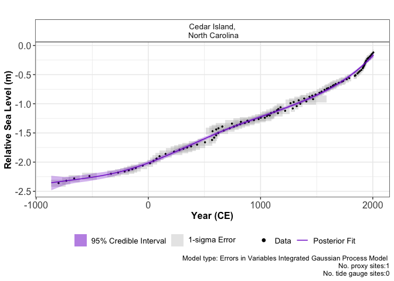

```r
plot(res_eiv_igp_t,
  plot_type = "model_fit_plot",
  xlab = "Year (CE)",
  ylab = "Relative Sea Level (m)",
  plot_proxy_records = TRUE,
  plot_tide_gauges = FALSE
)
```

The output of this function is a graph of the input data, i.e. Age and RSL and associated uncertainty boxes, and the model fit with 95 % credible interval. The caption provides the model type used and number of proxy sites and tide gauge sites used and can be removed if necessary with `plot_caption = FALSE`. In order to view the rate of change plot, the following setting should be used:

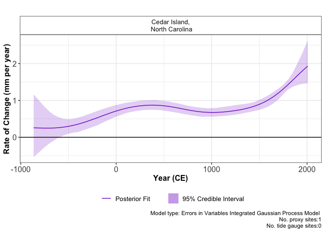

```r
plot(res_eiv_igp_t,
  plot_type = "rate_plot",
  xlab = "Year (CE)",
  y_rate_lab = "Rate of Change (mm per year)"
)
```

This prints the plot of the rate of change with 95 % credible intervals. The caption provides the model type, the number of proxy sites and tide gauge sites that were used.

To examine the data creating these plots the user types the following:

```r
output_dataframes <- res_eiv_igp_t$output_dataframes
head(output_dataframes)
```

```
#> # A tibble: 6 × 12
#>   Longitude Latitude SiteName     data_type_id   Age  pred   upr   lwr rate_pred
#>       <dbl>    <dbl> <fct>        <fct>        <dbl> <dbl> <dbl> <dbl>     <dbl>
#> 1     -76.4     35.0 "Cedar Isla… ProxyRecord  -865. -2.35 -2.48 -2.23     0.257
#> 2     -76.4     35.0 "Cedar Isla… ProxyRecord  -750  -2.32 -2.40 -2.26     0.248
#> 3     -76.4     35.0 "Cedar Isla… ProxyRecord  -700  -2.31 -2.37 -2.25     0.248
#> 4     -76.4     35.0 "Cedar Isla… ProxyRecord  -650  -2.30 -2.36 -2.24     0.252
#> 5     -76.4     35.0 "Cedar Isla… ProxyRecord  -600  -2.29 -2.34 -2.23     0.262
#> 6     -76.4     35.0 "Cedar Isla… ProxyRecord  -550  -2.27 -2.33 -2.21     0.277
#> # ℹ 3 more variables: rate_upr <dbl>, rate_lwr <dbl>, CI <chr>
```

# Noisy Input Generalised Additive Model in time (**“ni_spline_t”**)

An alternative method to examine how the response variable varies in time is using the temporal Noisy Input Generalised Additive Model (ni_spline_t). It model can obtain results in more efficient computational run times when compared with the eiv_igp_t model.

This technique focuses on 1 site and we do not recommended for multiple proxy sites together. Tide gauge data can be used to gain insight into recent RSL changes. As an example, we will filter the example dataset `NAACproxydata` to select one site to demonstrate the process:

```r
# For 1 site
CedarIslandNC <- reslr::NAACproxydata %>% dplyr::filter(Site == "Cedar Island")
```

**Step 1:** Load in the data using the `reslr_load` function:

```r
CedarIslandNC_input <- reslr_load(
  data = CedarIslandNC,
  include_tide_gauge = FALSE,
  include_linear_rate = FALSE,
  TG_minimum_dist_proxy = FALSE,
  list_preferred_TGs = NULL,
  all_TG_1deg = FALSE,
  prediction_grid_res = 50,
  sediment_average_TG = 10
)
```

In this function, the user can select to add tide gauge data and estimates for linear_rate, by changing `include_tide_gauge = TRUE` and `include_linear_rate = TRUE` respectfully. If `include_tide_gauge = TRUE` the user must decide if they require the closest tide gauge i.e. `TG_minimum_dist_proxy = TRUE`, or select specific tide gauge i.e. `list_preferred_TGs = c("ARGENTIA")`, or all tide gauges within 1 degree of the proxy site i.e. `all_TG_1deg = TRUE`. The default setting is `sediment_average_TG = 10` which corresponds to sediment accumulation rates of the proxy records, yet the user has the ability to alter this sediment accumulation rate by changing the size of the rolling window average.

Note that for a spline in time, we recommend using the default settings as demonstrated in the above code chunk. The user can alter the resolution of the output plots using `prediction_grid_res` with the default set at 50 years. The output of this function is a list of two dataframes called `data` and `data_grid`. - The `data` dataframe is the inputted data with additional columns for the data_type_id which will contain “ProxyRecord”. It can be accessed by:

```r
data <- CedarIslandNC_input$data
```

- The `data_grid` is a dataframe that is evenly spaced in time based on the `prediction_grid_res` value chosen by the user and is used to create the plots and is accessed by

```r
data_grid <- CedarIslandNC_input$data_grid
```

**Step 1a:** A brief insight into the outputs of the `reslr_input` function can be obtained using:

```r
print(CedarIslandNC_input)
```

```
#> This is a valid reslr input object with 104 observations and  1 site.
#> There is  1  proxy site and  0  tide gauge site.
#> The age units are; Common Era.
#> No decadally averaged yide gauge data included. It is recommended for the ni_gam_decomp model
#> No linear_rate or linear_rate_err included. It is required for the ni_gam_decomp model
```

**Step 2:** Plotting the data the raw data with:

```r
plot(
  x = CedarIslandNC_input,
  title = "Plot of the raw data",
  xlab = "Year (CE)",
  ylab = "Relative Sea Level (m)",
  plot_proxy_records = TRUE,
  plot_tide_gauges = FALSE
)
```

This will produce a plot of Age on the x-axis and Relative Sea Level on the y-axis in meters. Grey boxes represent the uncertainty associated with the vertical and horizontal uncertainty. The black data points are the midpoints of these uncertainty boxes. The following extra arguments can be used which allows the user to updated the titles and axis labels. The caption `plot_caption`, included by default, provides the number of proxy sites and tide gauge sites that will be used in the model and can be removed if required `plot_caption = FALSE`. In addition, the user can select to plot the additional tide gauge data, `plot_tide_gauge = TRUE`.

**Step 3:** To run this model type use the following:

```r
res_ni_spline_t <- reslr_mcmc(
  input_data = CedarIslandNC_input,
  model_type = "ni_spline_t",
  CI = 0.95
)
```

The output object `res_ni_spline_t` stores the JAGS model run. The `CI` setting allows the user to set the credible intervals, the current default is `CI = 0.95`. Note that there will be two model runs printed in the console here but the output will be the same format as earlier models.

**Step 3a:** A brief insight into the outputs of the `reslr_output` function can be obtained using:

```r
print(res_ni_spline_t)
```

```
#> This is a valid reslr output object with 104 observations and  1 site.
#> There is  1  proxy site and  0  tide gauge site.
#> The age units are; Common Era.
#> The model used was the Noisy Input Spline in time model.
#> The input data has been run via reslr_mcmc and has produced 3000 iterations over 3 MCMC chains.
```

**Step 4:** The convergence of the algorithm is examined and he parameter estimates from the model can be investigated using the following:

```r
summary(res_ni_spline_t)
```

```
#> No convergence issues detected.
#> # A tibble: 2 × 7
#>   variable      mean      sd     mad       q5    q95  rhat
#>   <chr>        <num>   <num>   <num>    <num>  <num> <num>
#> 1 sigma_beta 2.12    0.698   0.546   1.30     3.41    1.00
#> 2 sigma_y    0.00635 0.00473 0.00466 0.000546 0.0153  1.00
```

If the model run has the package will print: “No convergence issues detected”. If the package prints: “Convergence issues detected, a longer run is necessary”. The user is required to update the `reslr_mcmc` function with additional iterations in the following manner:

```r
res_ni_spline_t <- reslr_mcmc(
  input_data = CedarIslandNC,
  model_type = "ni_spline_t",
  # Update these values
  n_iterations = 6000, # Number of iterations
  n_burnin = 1000, # Number of iterations to discard at the beginning
  n_thin = 4, # Reduces number of output samples to save memory and computation time
  n_chains = 3 # Number of Markov chains
)
```

For the parameter estimates, we can present the standard deviation associated with the NI spline time model. Where “sigma_beta” highlights the variation associated with the spline coefficient for the spline in time and “sigma_y” presenting the overall variation of the model.

**Step 5:** the results from the ni_spline_t model can be illustrated using:

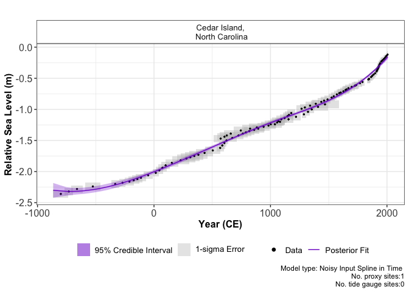

```r
plot(res_ni_spline_t,
  plot_type = "model_fit_plot",
  xlab = "Year (CE)",
  ylab = "Relative Sea Level (m)"
)
```

The output of this function is a graph of the input data, i.e. Age and RSL and associated uncertainty boxes, and the model fit with 95 % credible interval. The caption provides the model type used and number of proxy sites and tide gauge sites used and can be removed if necessary with `plot_caption = FALSE`. In order to view the rate of change plot, the following setting should be used:

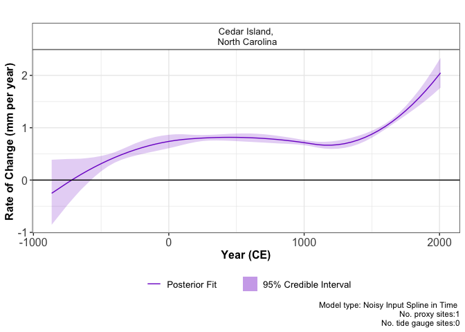

```r
plot(res_ni_spline_t,
  plot_type = "rate_plot",
  xlab = "Year (CE)",
  y_rate_lab = "Rate of Change (mm per year)"
)
```

This prints the plot of the rate of change with 95 % credible intervals. Again, the caption provides the model type, number of proxy sites and tide gauge sites that were used.

To examine the data creating these plots the user types the following:

```r
output_dataframes <- res_ni_spline_t$output_dataframes
head(output_dataframes)
```

```
#>   Longitude Latitude                       SiteName data_type_id     Age
#> 1    -76.38   34.971 Cedar Island,\n North Carolina  ProxyRecord -865.25
#> 2    -76.38   34.971 Cedar Island,\n North Carolina  ProxyRecord -750.00
#> 3    -76.38   34.971 Cedar Island,\n North Carolina  ProxyRecord -700.00
#> 4    -76.38   34.971 Cedar Island,\n North Carolina  ProxyRecord -650.00
#> 5    -76.38   34.971 Cedar Island,\n North Carolina  ProxyRecord -600.00
#> 6    -76.38   34.971 Cedar Island,\n North Carolina  ProxyRecord -550.00
#>        pred       upr       lwr   rate_pred    rate_upr  rate_lwr  CI
#> 1 -2.300519 -2.419247 -2.183666 -0.25246147 -0.85427174 0.3886378 95%
#> 2 -2.318172 -2.386823 -2.252127 -0.05399433 -0.48045997 0.4026723 95%
#> 3 -2.318811 -2.375323 -2.262713  0.02775875 -0.33140823 0.4053084 95%
#> 4 -2.315465 -2.366167 -2.264344  0.10538302 -0.18745319 0.4085071 95%
#> 5 -2.308341 -2.358076 -2.258699  0.17887847 -0.06183556 0.4209172 95%
#> 6 -2.297646 -2.345493 -2.247588  0.24824510  0.06121631 0.4370932 95%
```

# Noisy input spline in space time (**“ni_spline_st”**)

The Noisy Input spline in space time examines changes in response over multiple locations and throughout time. For this model, a minimum of 2 proxy sites should be used and tide gauge data provides insight into recent changes in RSL if the user is requires_ As an example, we will filter the example dataset `NAACproxydata` to select two sites to demonstrate the process:

```r
# For 2 site
multi_site <- reslr::NAACproxydata %>%
  dplyr::filter(Site %in% c("Cedar Island", "Nassau"))
```

**Step 1:** Load in the data using the `reslr_load` function:

```r
multi_site_input <- reslr_load(
  data = multi_site,
  include_tide_gauge = FALSE,
  include_linear_rate = FALSE,
  TG_minimum_dist_proxy = FALSE,
  list_preferred_TGs = NULL,
  all_TG_1deg = FALSE,
  prediction_grid_res = 50,
  sediment_average_TG = 10
)
```

Note that for a spline in space time, we recommend using the default settings as demonstrated in the above code chunk or investigating the resulting plots if additional tide gauge data could provide insight into recent changes. The user can alter the resolution of the output plots using `prediction_grid_res` with the default set at 50 years. The output of this function is a list of two dataframes called `data` and `data_grid`. - The `data` dataframe is the inputted data with additional columns for the linear_rate, linear_rate_err and data_type_id which will contain two options, “ProxyRecord” or “TideGaugeData”. It can be accessed by:

```r
data <- multi_site_input$data
head(data)
```

```
#>    Region   Site Latitude Longitude   RSL  Age Age_err RSL_err
#> 1 Florida Nassau   30.587   -81.666  0.05 2002    4.25    0.07
#> 2 Florida Nassau   30.587   -81.666  0.03 1990    5.50    0.07
#> 3 Florida Nassau   30.587   -81.666  0.01 1980    4.25    0.07
#> 4 Florida Nassau   30.587   -81.666 -0.01 1974    4.50    0.07
#> 5 Florida Nassau   30.587   -81.666 -0.03 1964    9.50    0.07
#> 6 Florida Nassau   30.587   -81.666 -0.05 1936   10.75    0.07
#>            SiteName data_type_id
#> 1 Nassau,\n Florida  ProxyRecord
#> 2 Nassau,\n Florida  ProxyRecord
#> 3 Nassau,\n Florida  ProxyRecord
#> 4 Nassau,\n Florida  ProxyRecord
#> 5 Nassau,\n Florida  ProxyRecord
#> 6 Nassau,\n Florida  ProxyRecord
```

- The `data_grid` is a dataframe that is evenly spaced in time based on the `prediction_grid_res` value chosen by the user and is used to create the plots and is accessed by

```r
data_grid <- multi_site_input$data_grid
head(data_grid)
```

```
#> # A tibble: 6 × 5
#> # Groups:   SiteName [2]
#>   Longitude Latitude SiteName                         data_type_id   Age
#>       <dbl>    <dbl> <fct>                            <fct>        <dbl>
#> 1     -76.4     35.0 "Cedar Island,\n North Carolina" ProxyRecord  -865.
#> 2     -76.4     35.0 "Cedar Island,\n North Carolina" ProxyRecord  -750
#> 3     -76.4     35.0 "Cedar Island,\n North Carolina" ProxyRecord  -700
#> 4     -76.4     35.0 "Cedar Island,\n North Carolina" ProxyRecord  -650
#> 5     -76.4     35.0 "Cedar Island,\n North Carolina" ProxyRecord  -600
#> 6     -81.7     30.6 "Nassau,\n Florida"              ProxyRecord  -570.
```

**Step 1a:** A brief insight into the outputs of the `reslr_input` function can be obtained using:

```r
print(multi_site_input)
```

```
#> This is a valid reslr input object with 169 observations and  2 sites.
#> There are  2  proxy sites and  0  tide gauge site.
#> The age units are; Common Era.
#> No decadally averaged yide gauge data included. It is recommended for the ni_gam_decomp model
#> No linear_rate or linear_rate_err included. It is required for the ni_gam_decomp model
```

**Step 2:** Plotting the data the raw data with:

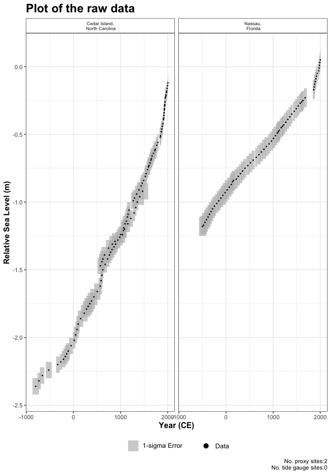

```r
plot(
  x = multi_site_input,
  title = "Plot of the raw data",
  xlab = "Year (CE)",
  ylab = "Relative Sea Level (m)",
  plot_proxy_records = TRUE,
  plot_tide_gauges = FALSE
)
```

This will produce a plot of Age on the x-axis and Relative Sea Level on the y-axis in meters. Grey boxes represent the uncertainty associated with the vertical and horizontal uncertainty. The black data points are the midpoints of these uncertainty boxes. The separate sites will appear in separate windows on the plot. The extra arguments can be used which allows the user to updated the titles and axis labels. The caption `plot_caption`, included by default, provides the number of proxy sites and tide gauge sites that will be used in the model and can be removed if required `plot_caption = FALSE`. In addition, the user can select to plot the additional tide gauge data, `plot_tide_gauge = TRUE`.

**Step 3:** Run the model for the two sites.

```r
res_ni_spline_st <- reslr_mcmc(
  input_data = multi_site_input,
  model_type = "ni_spline_st",
  CI = 0.95
)
```

**Step 3a:** A brief insight into the outputs of the `reslr_output` function can be obtained using:

```r
print(res_ni_spline_st)
```

```
#> This is a valid reslr output object with 169 observations and  2 sites.
#> There are  2  proxy sites and  0  tide gauge site.
#> The age units are; Common Era.
#> The model used was the Noisy Input Spline in space time model.
#> The input data has been run via reslr_mcmc and has produced 3000 iterations over 3 MCMC chains.
```

**Step 4:** The convergence of the algorithm is examined and he parameter estimates from the model can be investigated using the following:

```r
summary(res_ni_spline_st)
```

```
#> No convergence issues detected.
#> # A tibble: 2 × 7
#>   variable      mean      sd     mad       q5    q95  rhat
#>   <chr>        <num>   <num>   <num>    <num>  <num> <num>
#> 1 sigma_beta 3.21    0.769   0.668   2.24     4.59    1.00
#> 2 sigma_y    0.00475 0.00357 0.00348 0.000338 0.0118  1.00
```

If the model run has the package will print: “No convergence issues detected”. If the package prints: “Convergence issues detected, a longer run is necessary”. The user is required to update the `reslr_mcmc` function with additional iterations in the following manner:

```r
res_ni_spline_st <- reslr::reslr_mcmc(
  input_data = multi_site_input,
  model_type = "ni_spline_st",
  # Update these values
  n_iterations = 6000, # Number of iterations
  n_burnin = 1000, # Number of iterations to discard at the beginning
  n_thin = 4, # Reduces number of output samples to save memory and computation time
  n_chains = 3 # Number of Markov chains
)
```

For the parameter estimates, we can present the standard deviation associated with the NI spline space time model. Where “sigma_beta” highlights the variation associated with the spline coefficient of the spline in time and “sigma_y” presenting the overall variation.

**Step 5:** the results from the ni_spline_st model can be illustrated using:

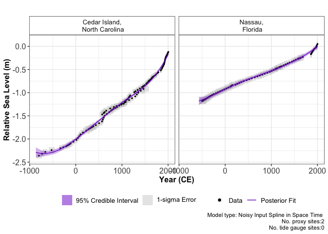

```r
plot(res_ni_spline_st,
  plot_type = "model_fit_plot",
  xlab = "Year (CE)",
  ylab = "Relative Sea Level (m)"
)
```

The output of this function is a graph of the input data, i.e. Age and RSL and associated uncertainty boxes, and the model fit with 95 % credible interval. The caption provides the model type used and number of proxy sites and tide gauge sites used and can be removed if necessary with `plot_caption = FALSE`. In order to view the rate of change plot, the following setting should be used:

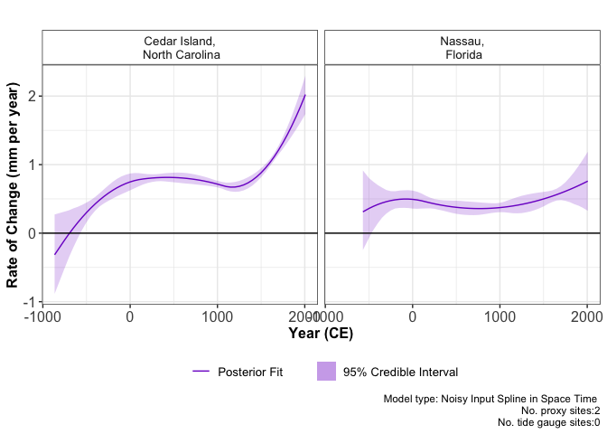

```r
plot(res_ni_spline_st,
  plot_type = "rate_plot",
  xlab = "Year (CE)",
  y_rate_lab = "Rate of Change (mm per year)"
)
```

This will print the plot of the rate of change with 95 % credible intervals. Again, the caption provides the model type, the number of proxy sites and tide gauge sites that were used.

To examine the data creating these plots the user types the following:

```r
output_dataframes <- res_ni_spline_st$output_dataframes
head(output_dataframes)
```

```
#>   Longitude Latitude                       SiteName data_type_id     Age
#> 1   -76.380   34.971 Cedar Island,\n North Carolina  ProxyRecord -865.25
#> 2   -76.380   34.971 Cedar Island,\n North Carolina  ProxyRecord -750.00
#> 3   -76.380   34.971 Cedar Island,\n North Carolina  ProxyRecord -700.00
#> 4   -76.380   34.971 Cedar Island,\n North Carolina  ProxyRecord -650.00
#> 5   -76.380   34.971 Cedar Island,\n North Carolina  ProxyRecord -600.00
#> 6   -81.666   30.587              Nassau,\n Florida  ProxyRecord -569.50
#>        pred       upr       lwr    rate_pred    rate_upr  rate_lwr  CI
#> 1 -2.288979 -2.402227 -2.178358 -0.315313061 -0.88533751 0.2727370 95%
#> 2 -2.312851 -2.381045 -2.245650 -0.098777056 -0.50904793 0.3150883 95%
#> 3 -2.315540 -2.374442 -2.256636 -0.009555977 -0.35018093 0.3341021 95%
#> 4 -2.313885 -2.365970 -2.262178  0.074982082 -0.20678899 0.3619208 95%
#> 5 -2.308120 -2.356545 -2.257258  0.154837120 -0.07264035 0.3842198 95%
#> 6 -1.178327 -1.272693 -1.085575  0.311147621 -0.24681288 0.9152990 95%
```

# Noisy Input Generalised Additive Model for decomposition of response signal (**“ni_gam_decomp”**)

The Noisy Input Generalised Additive Model for the decomposition of the response signal (RSL). In the case of RSL, there are different drivers influence the changing RSL signal and these drivers vary in time and space. .The three main components of RSL change being examined using this model type at a regional, local linear component and non-linear local component. A detailed description of this model can be found [here](https://arxiv.org/abs/2301.09556).

There are a number of settings within the package that are important when using this model type. For the local linear component, GIA rate and associated uncertainty of the GIA rate must be provided prior to running. If the GIA rate is not provided for each location, then the `reslr` package will calculate it using the data and if this is not possible, the package will print an error message. Also, we recommend using tide gauge data averaged over a decade to match the accumulation rates of the proxy records, which is an additional argument in the function.

This model needs an adequate number of proxy sites to perform the decomposition and the minimum sites required will depend on the signal of the data. We found that in general we need a minimum of five proxy sites and at least five associated tide gauge sites. Also, we strongly recommend using tide gauge data for this model to obtain insight into recent changes in RSL.

```r
# For 9 site
multi_9_sites <- reslr::NAACproxydata %>%
  dplyr::filter(Site %in% c(
    "Cedar Island", "Nassau", "Snipe Key",
    "Placentia", "Cape May Courthouse", "East River Marsh",
    "Fox Hill Marsh", "Swan Key", "Big River Marsh"
  ))
```

**Step 1:** Load in the data using the `reslr_load` function:

```r
multi_9_sites_input <- reslr_load(
  data = multi_9_sites,
  include_tide_gauge = TRUE,
  include_linear_rate = TRUE,
  TG_minimum_dist_proxy = FALSE,
  list_preferred_TGs = NULL,
  all_TG_1deg = TRUE,
  prediction_grid_res = 50,
  sediment_average_TG = 10
)
```

```
#> Package calculated linear_rate and linear_rate_err using the input data.
#> Selecting all tide gauges within 1 degree of the proxy site
```

In this function, the user can select to add tide gauge data and estimates for linear_rate, by changing `include_tide_gauge = TRUE` and `include_linear_rate = TRUE` respectfully. If `include_tide_gauge = TRUE` the user must decide if they require the closest tide gauge i.e. `TG_minimum_dist_proxy = TRUE`, or select specific tide gauge i.e. `list_preferred_TGs = c("ARGENTIA")`, or all tide gauges within 1 degree of the proxy site i.e. `all_TG_1deg = TRUE`. In this example, we use all tide gauges within 1 degree of the proxy site. The default setting is `sediment_average_TG = 10` which corresponds to sediment accumulation rates of the proxy records, yet the user has the ability to alter this sediment accumulation rate.

Note that for this model, we recommend using the default settings as demonstrated in the above code chunk. If the user has not provided the linear rate and the associated linear rate uncertainty within the `linear_rate` and `linear_rate_err` column prior to running the package, the package to calculate it using the data.

The output of this function is a list of two dataframes called `data` and `data_grid`. - The `data` dataframe is the inputted data with additional columns for the linear_rate, linear_rate_err and data_type_id which will contain two options, “ProxyRecord” or “TideGaugeData”. It can be accessed by:

```r
data <- multi_9_sites_input$data
```

- The `data_grid` is a dataframe that is evenly spaced in time based on the `prediction_grid_res` value chosen by the user and is used to create the plots and is accessed by

```r
data_grid <- multi_9_sites_input$data_grid
```

**Step 1a:** A brief insight into the outputs of the `reslr_input` function can be obtained using:

```r
print(multi_9_sites_input)
```

```
#> This is a valid reslr input object with 1124 observations and  36 sites.
#> There are  9  proxy sites and  27  tide gauge sites.
#> The age units are; Common Era.
#> Decadally averaged tide gauge data included by the package.
#> The linear_rate and linear_rate_err included.
```

**Step 2:** Plotting the data the raw data with:

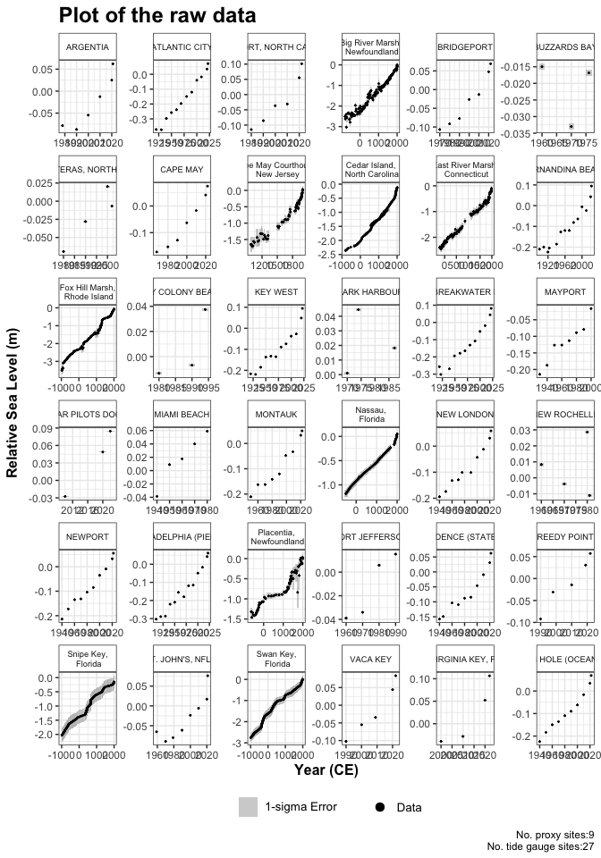

```r
plot(
  x = multi_9_sites_input,
  title = "Plot of the raw data",
  xlab = "Year (CE)",
  ylab = "Relative Sea Level (m)",
  plot_proxy_records = TRUE,
  plot_tide_gauges = TRUE
)
```

This will produce a plot of Age on the x-axis and Relative Sea Level on the y-axis in meters. Grey boxes represent the uncertainty associated with the vertical and horizontal uncertainty. The black data points are the midpoints of these uncertainty boxes. The separate sites will appear in separate windows on the plot. The extra arguments can be used which allows the user to updated the titles and axis labels. The caption `plot_caption`, included by default, provides the number of proxy sites and tide gauge sites that will be used in the model and can be removed if required `plot_caption = FALSE`. In addition, the user can select to plot the additional tide gauge data, `plot_tide_gauge = TRUE`.

**Step 3:** Run the model

```r
res_ni_gam_decomp <- reslr_mcmc(
  input_data = multi_9_sites_input,
  model_type = "ni_gam_decomp",
  CI = 0.95
)
```

The output object `res_ni_gam_decomp` stores the JAGS model run. The `CI` setting allows the user to set the credible intervals, the current default is `CI = 0.95`. Note that there will be two model runs printed in the console here but the output will be the same format as earlier models.

**Step 3a:** A brief insight into the outputs of the `reslr_output` function can be obtained using:

```r
print(res_ni_gam_decomp)
```

```
#> This is a valid reslr output object with 1124 observations and  36 sites.
#> There are  9  proxy sites and  27  tide gauge sites.
#> The age units are; Common Era.
#> The model used was the Noisy Input Generalised Additive Model for decomposition of the RSL signal.
#> The input data has been run via reslr_mcmc and has produced 3000 iterations over 3 MCMC chains.
```

**Step 4:** The convergence of the algorithm is examined and he parameter estimates from the model can be investigated using the following:

```r
summary(res_ni_gam_decomp)
```

```
#> No convergence issues detected.
#> # A tibble: 4 × 7
#>   variable       mean      sd     mad     q5    q95  rhat
#>   <chr>         <num>   <num>   <num>  <num>  <num> <num>
#> 1 sigma_beta_h 0.878  0.138   0.130   0.679  1.12    1.00
#> 2 sigma_beta_r 1.77   0.433   0.388   1.19   2.58    1.00
#> 3 sigma_beta_l 1.39   0.240   0.236   1.02   1.80    1.00
#> 4 sigma_y      0.0150 0.00123 0.00119 0.0130 0.0171  1.00
```

If the model run has the package will print: “No convergence issues detected”. If the package prints: “Convergence issues detected, a longer run is necessary”. The user is required to update the `reslr_mcmc` function with additional iterations in the following manner:

```r
res_ni_gam_decomp <- reslr_mcmc(
  input_data = multi_9_sites_input,
  model_type = "ni_gam_decomp",
  # Update these values
  n_iterations = 6000, # Number of iterations
  n_burnin = 1000, # Number of iterations to discard at the beginning
  n_thin = 4, # Reduces number of output samples to save memory and computation time
  n_chains = 3 # Number of Markov chains
)
```

For the parameter estimates, we can present the standard deviation associated with each component of the NIGAM decomposition. This gives an insight into the variation caused by the different components with “sigma_r” representing the regional component, “sigma_l” highlighting the non-linear local component, “sigma_y” presenting the overall variation and “sigma_h” representing the site specific vertical offset.

**Step 5:** The results from the `ni_gam_decomp` model can be illustrated with the option of excluding the tide gauge using:

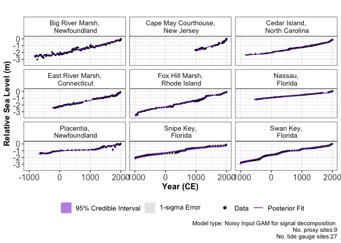

```r
plot(res_ni_gam_decomp,
  plot_type = "model_fit_plot",
  plot_tide_gauge = FALSE
)
```

In addition, the user can select to plot the additional tide gauge data, `plot_tide_gauge = TRUE` in the plot. The output of this function is a graph of the input data, i.e. Age and RSL and associated uncertainty boxes, and the model fit with 95 % credible interval. The caption provides the model type used and number of proxy sites and tide gauge sites used and can be removed if necessary with `plot_caption = FALSE`. In order to view the rate of change plot, the following setting should be used:

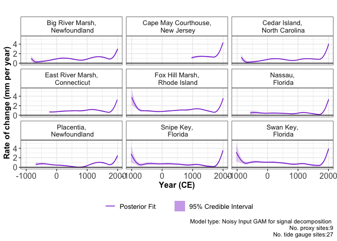

```r
plot(res_ni_gam_decomp,
  plot_type = "rate_plot"
)
```

This will print the plot of the rate of change with 95 % credible intervals. The caption provides the model type, the number of proxy sites and tide gauge sites that were used. To examine the data creating the total model fit result plot, the user can use:

```r
total_model_fit_df <- res_ni_gam_decomp$output_dataframes$total_model_fit_df
head(total_model_fit_df)
```

```
#>   Longitude Latitude                       SiteName linear_rate linear_rate_err
#> 1     -80.3     25.3            Swan Key,\n Florida   0.9111252      0.01544944
#> 2     -81.7     24.7           Snipe Key,\n Florida   0.6579198      0.01008171
#> 3     -71.4     41.5 Fox Hill Marsh,\n Rhode Island   1.0003208      0.01353693
#> 4     -81.7     24.7           Snipe Key,\n Florida   0.6579198      0.01008171
#> 5     -80.3     25.3            Swan Key,\n Florida   0.9111252      0.01544944
#> 6     -71.4     41.5 Fox Hill Marsh,\n Rhode Island   1.0003208      0.01353693
#>   data_type_id     Age      pred       upr       lwr                    ID  CI
#> 1  ProxyRecord -1030.5 -2.972499 -3.163550 -2.777439 Total Posterior Model 95%
#> 2  ProxyRecord -1019.5 -2.236372 -2.421797 -2.041795 Total Posterior Model 95%
#> 3  ProxyRecord -1001.5 -3.469720 -3.626950 -3.310323 Total Posterior Model 95%
#> 4  ProxyRecord  -943.0 -2.056510 -2.166989 -1.941491 Total Posterior Model 95%
#> 5  ProxyRecord  -943.0 -2.736931 -2.837306 -2.633119 Total Posterior Model 95%
#> 6  ProxyRecord  -943.0 -3.273894 -3.362579 -3.185296 Total Posterior Model 95%
```

To examine the data creating the total model rate of change plot the user can use:

```r
total_model_rate_df <- res_ni_gam_decomp$output_dataframes$total_model_rate_df
head(total_model_rate_df)
```

```
#>   Longitude Latitude                       SiteName linear_rate linear_rate_err
#> 1     -80.3     25.3            Swan Key,\n Florida   0.9111252      0.01544944
#> 2     -81.7     24.7           Snipe Key,\n Florida   0.6579198      0.01008171
#> 3     -71.4     41.5 Fox Hill Marsh,\n Rhode Island   1.0003208      0.01353693
#> 4     -81.7     24.7           Snipe Key,\n Florida   0.6579198      0.01008171
#> 5     -80.3     25.3            Swan Key,\n Florida   0.9111252      0.01544944
#> 6     -71.4     41.5 Fox Hill Marsh,\n Rhode Island   1.0003208      0.01353693
#>   data_type_id     Age rate_pred  rate_upr rate_lwr
#> 1  ProxyRecord -1030.5  3.164996 1.2446748 4.992418
#> 2  ProxyRecord -1019.5  2.805951 0.9914535 4.544467
#> 3  ProxyRecord -1001.5  3.806483 2.1306016 5.436847
#> 4  ProxyRecord  -943.0  1.884636 0.8153738 2.889094
#> 5  ProxyRecord  -943.0  2.172919 1.0925466 3.196253
#> 6  ProxyRecord  -943.0  2.909556 1.8372466 4.001848
#>                                         ID  CI
#> 1 Total Rate of Change for Posterior Model 95%
#> 2 Total Rate of Change for Posterior Model 95%
#> 3 Total Rate of Change for Posterior Model 95%
#> 4 Total Rate of Change for Posterior Model 95%
#> 5 Total Rate of Change for Posterior Model 95%
#> 6 Total Rate of Change for Posterior Model 95%
```

There are separate settings to examine the plot of each component and its associated rate. To examine the regional component plot use:

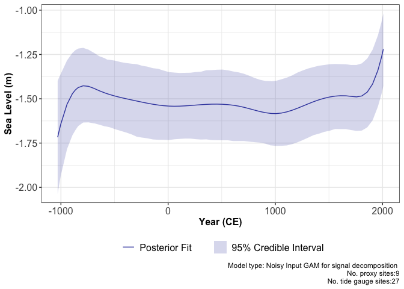

```r
plot(res_ni_gam_decomp, plot_type = "regional_plot")
```

The regional component and the rate of change of the regional component is presented with 95% credible interval. The caption provides the model type used and number of proxy sites and tide gauge sites used and can be removed if necessary with `plot_caption = FALSE`. To examine the data creating the regional component plot, the user can use:

```r
regional_component_df <- res_ni_gam_decomp$output_dataframes$regional_component_df
```

The rate for the regional component can be accessed using:

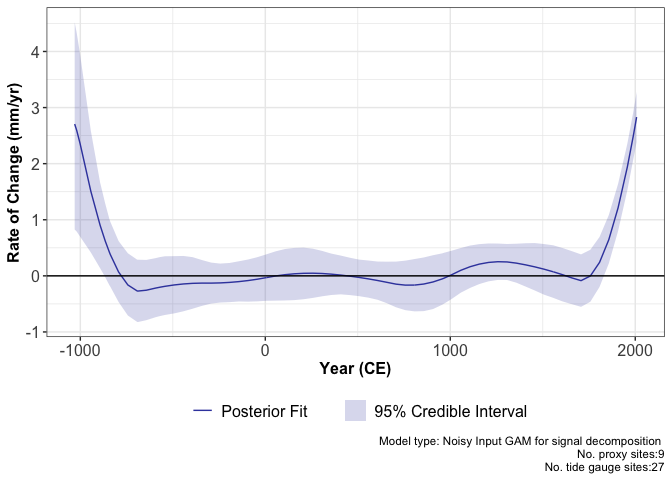

```r
plot(res_ni_gam_decomp, plot_type = "regional_rate_plot")
```

Similarly, the rate of change of the regional component is presented with 95% credible interval. The caption provides the model type used and number of proxy sites and tide gauge sites used and can be removed if necessary with `plot_caption = FALSE`. To examine the data creating the regional component rate of change plot the user can use:

```r
regional_rate_component_df <- res_ni_gam_decomp$output_dataframes$regional_rate_component_df
```

To examine the linear local component plot use:

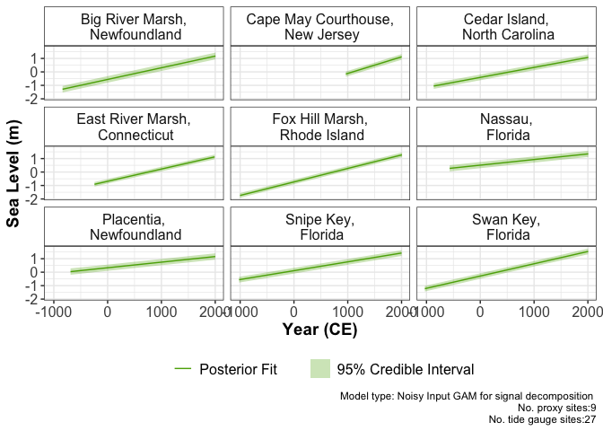

```r
plot(res_ni_gam_decomp, plot_type = "linear_local_plot")
```

The linear local component is plotted with 95% credible interval. The caption provides the model type used and number of proxy sites and tide gauge sites used and can be removed if necessary with `plot_caption = FALSE`. To examine the data creating the linear local component plot, the user can use:

```r
lin_loc_component_df <- res_ni_gam_decomp$output_dataframes$lin_loc_component_df
```

The associated linear local component rates for each location can be accessed by:

```r
lin_loc_component_rates <- lin_loc_component_df %>%
  dplyr::group_by(SiteName) %>%
  dplyr::summarise(
    linear_rate = unique(linear_rate),
    linear_rate_err = unique(linear_rate_err)
  )
```

To examine the non-linear local component plot use:

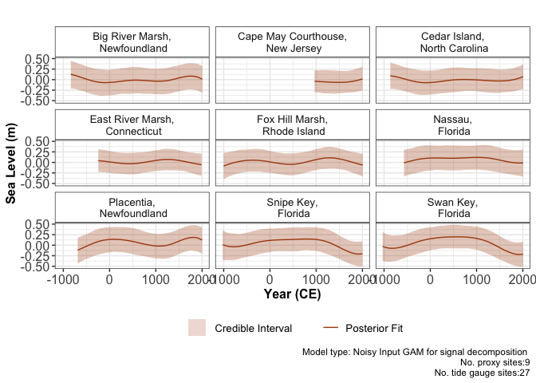

```r
plot(res_ni_gam_decomp, plot_type = "non_linear_local_plot")
```

The non-linear local component is plotted with with 95% credible interval. The caption provides the model type used and number of proxy sites and tide gauge sites used and can be removed if necessary with `plot_caption = FALSE`. To examine the data creating the non-linear local component plot, the user can use:

```r
non_lin_loc_component_df <- res_ni_gam_decomp$output_dataframes$non_lin_loc_component_df
```

The plot of the rate of change for the non-linear local component use:

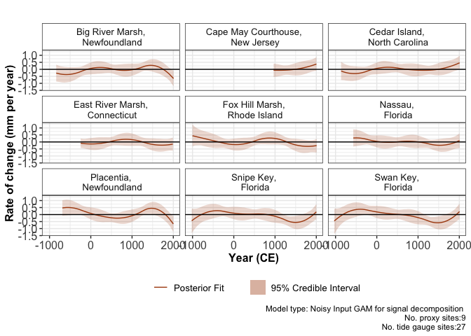

```r
plot(res_ni_gam_decomp, plot_type = "non_linear_local_rate_plot")
```

The rate of change of the non-linear local component is plotted with with 95% credible interval. The caption provides the model type used and number of proxy sites and tide gauge sites used and can be removed if necessary with `plot_caption = FALSE`.

To examine the data creating the non-linear local component plot rate of change plot the user can use:

```r
non_lin_loc_rate_component_df <- jags_output.ni_gam_decomp$output_dataframes$non_lin_loc_rate_component_df
```

In order to examine how all components vary, the user can examine the plot using the following method:

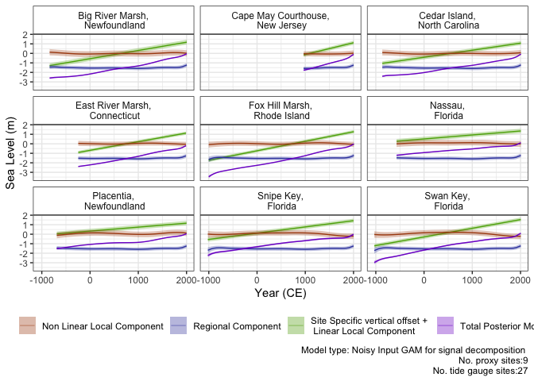

```r
plot(res_ni_gam_decomp, plot_type = "nigam_component_plot")
```

Each component is plotted with an 95% credible interval and this plot gives insight into the variability of the different components through time and at the different locations in question. The caption provides the model type used and number of proxy sites and tide gauge sites used and can be removed if necessary with `plot_caption = FALSE`.

# Appendix - suggested reading

For an introduction into statistical modelling for relative sea level change:

Upton, Maeve, Cahill, Niamh and Parnell, Andrew C. (2023), ‘Statistical Modelling for Relative Sea-Level Data’, Reference Module in Earth Systems and Environmental Sciences, Elsevier

For the maths on the original Change Point models:

Cahill, Niamh, Rahmstorf, Stefan and Parnell Andrew C. (2015), ‘Change points of global temperature’, Environmental Research Letters, 10(8), 084002

For the maths on the original EIV models:

Cahill, Niamh, Kemp, Andrew C , Horton, Benjamin P and Parnell, Andrew C (2015), ‘Modeling sea-level change using Errors-in-Variables integrated Gaussian Process 1’, The Annals of Applied Statistics 9(2), 547–571

For the maths on the original NIGAM: Upton, Maeve, Parnell, Andrew C, Kemp, Andrew C , Ashe, Erica, McCarthy, Gerard and Cahill, Niamh (2023) ‘A noisy-input generalised additive model for relative sea-level change along the Atlantic coast of North America’

For the background of GIA rates:

Whitehouse, Pippa L (2018), ‘Glacial isostatic adjustment modelling: historical perspectives, recent advances, and future directions’, Earth Surf. Dynam 6, 401–429.

Engelhart, Simon E., Benjamin P. Horton, Bruce C. Douglas, W. Richard Peltier and Torbj&oorn E. T ̈ornqvist (2009), ‘Spatial variability of late Holocene and 20th century sea-level rise along the Atlantic coast of the United States’, Geology 37(12), 1115–1118

Peltier, W.R (2004), ‘Global Glacial Isostasy and the Surface of the Ice-Age Earth: The ICE-5G (VM2) Model and GRACE’, Annual Review of Earth and Planetary Sciences 32, 111–149

For the background to tide gauge data:

Pugh, David, and rholip Woodworth. 2014. “Tidal Forces: Sea-Level Science: Understanding Tides, Surges, Tsunamis and Mean Sea-Level Changes.” In Sea-Level Science: Understanding Tides, Surges, Tsunamis and Mean Sea-Level Changes, 36–59. Cambridge University Press.

Holgate, Simon J., Andrew Matthews, rholip L. Woodworth, Lesley J. Rickards, Mark E. Tamisiea, Elizabeth Bradshaw, Peter R. Foden, Kathleen M. Gordon, Svetlana Jevrejeva, and Jeff Pugh. 2013. “New Data Systems and Products at the Permanent Service for Mean Sea Level.” Journal of Coastal Research 29 (3): 493–504.